© Guven

# Recommender Systems

## Introduction

Today, we interact with recommender systems on a regular basis, when we use digital services and applications, from online retailers, to movie and TV services, and news aggregators. These are algorithms that make suggestions about what a user may like, such as a specific movie. They are functions that take information about a user's preferences as an input, and generate a prediction about the rating that a user would give of the items under evaluation, and predict how they would rank a set of items individually or as a bundle. Recommender systems collect, curate, and act upon vast amounts of personal data. Inevitably, they end up shaping individual experience of digital environments and social interactions.

The basic principle of recommendation methods is based on the assumption (or fact?) that significant dependencies exist between the user and the items. As an example, a user who is interested in a historical second world war documentary is more likely to be interested in another historical documentary, or an educational program, rather than in an action movie. In many cases, various categories of items may show significant correlations, which can be leveraged to make more accurate recommendations based on this similarity.

Alternatively, the dependencies may be present at the finer granularity of individual items rather than categories. These dependencies can be learned in a data-driven approach from the ratings matrix, and the resulting model is used to make predictions for target users. The larger the number of rated items that are available for a user, the easier it is to make robust predictions about the future behavior of the user. A variety of learning models can be used to accomplish this task. For example, the collective buying or rating behavior of various users can be leveraged to create cohorts of similar users that are interested in similar products. The interests and actions of these cohorts can be leveraged to make recommendations to individual members of these cohorts.

These above approaches can be referred to as neighborhood models, or referred to as collaborative filtering. The term *collaborative filtering* refers to the use of ratings from multiple users in a collaborative way to predict missing ratings. In practice, recommender systems can be more complex and data enriched. For example, in content-based recommender systems, the content plays a primary role in the recommendation process, in which the ratings of users and the attribute descriptions of items are leveraged in order to make predictions. The basic idea is that user interests can be modeled on the basis of properties (or attributes) of the items they have rated or accessed in the past. A different framework is that of knowledge-based systems, in which users interactively specify their interests, and the user specification is combined with domain knowledge to provide recommendations. In advanced models, contextual data, such as temporal information, external knowledge, location information, social information, or network information, can also be used.

In this module we will build a recommender system on the MovieLens dataset which is composed five sub-datasets of (1.) movies, (2.) movie ratings, (3.) movie tags, (4.) tags to describe movies by users, and (5.) movie tag scores.

## Distance/Similarity Measures

A distance metric, $d:X\times X \longrightarrow [0,\infty) \in \mathbb{R}^+$, satisfies the following:

| Property | Name |
| --- | --- |
| $d(x,y)\ge 0$ | non-negative |
| $d(x,y)=0 \iff x=y$ | identity |
| $d(x,y)=d(y,x)$ | symmetry |
| $$d(x,y)\le d(x,z)+d(z,y)$$ | triangle inequality |

Define $d_{ij}$ = the distance between the user $i$ and $j$, where there are $N$ users, $M$ movies, and $X$ as the movie ratings of users as $x\in \mathbb{R}^{N\texttt{x}M}$.  
Define $I_i$ as the set of movies user $i$ rated, where $i \in \{1,2,\dots,N\}$ and $I_i \in \mathbb{P}(\{1,2,\dots,M\})$.

| Name | Distance |
| --- | --- |
| Jaccard index | $d_{ij}= \dfrac{x_i \cap x_j}{x_i \cup x_j}$ |
| Cosine similarity | $d_{ij}=\cos(\theta)=\dfrac{x_i \cdot x_j}{\|x_i\| \|x_j\|}$ |
| Pearson | $$d_{ij}= \frac {\sum_{k \in I_i \cap I_j} (x_{ik}-\mu_i)(x_{jk}-\mu_j)} {\sqrt{\sum_{k \in I_i \cap I_j} (x_{ik}-\mu_i)^2}\sqrt{\sum_{k \in I_i \cap I_j} (x_{jk}-\mu_j)^2}} $$ |
| Manhattan distance, L$_1$ | $d_{ij}=\sum_{k\in I_i \cap I_j}{\|x_{ik}-x_{jk}\|}$ |
| Euclidean distance, L$_2$ | $d_{ij}=\sqrt{\sum_{k \in I_i \cap I_j} (x_{ik}-x_{jk})^2}$ |
| Chebyshev distance | $d_{ij}= \max_{k \in I_i \cap I_j} \|x_{ik}-x_{jk}\|$ |

The following table can be used as guideline to apply distance metrics

| Data | Example | Similarity |
| --- | --- | --- |
| Unary (contains only likes) Transactions of items bought | user$_1$ likes mov$_2$ user$_2$ likes mov$_1$ user$_3$ likes mov$_3$ | Jaccard |
| Binary (two possible values) Likes and dislikes | user$_1$ likes mov$_2$ user$_2$ likes mov$_1$ user$_2$ dislikes mov$_2$ user$_3$ likes mov$_3$ | Jaccard |
| Quantitative and ordered Ratings | user$_1$ 5-star to mov$_2$ user$_2$ 4-star to mov$_1$ user$_2$ 1-star to mov$_2$ user$_3$ 3-star to mov$_3$ | Pearson Cosine |

### Dataset and Feature Exploration

- Examine the dataset, sanity checks, extract indices
  - Original movie dataset is exported from a database
- Extract Genres
- Limit the number of users `USERS_N` for faster processing
- Use a threshold `RATINGS_N_MIN` to ease the pre-processing
  - movies with little information may not help
- `Ratings` matrix, `N` users and `M` movies are stored in an order 2 tensor for faster processing
- Implement distance metrics
- Inspect distance metrics on users
  - What is the feature vector?

Let's see how we use distance/similarity metrics to find and rate movies.

```python
%matplotlib inline
import matplotlib.pyplot as plt
plt.rcParams["figure.dpi"] = 72
import numpy as np
import pandas as pd
import re
from collections import defaultdict
```

```python
# A subset of the dataset to shorten the pipeline processing
USERS_N = 1000
```

```python
# read datasets
df_movies = pd.read_csv('../../../EP_datasets/movielens_movie.csv')
df_ratings = pd.read_csv('../../../EP_datasets/movielens_rating.csv')
df_tag = pd.read_csv('../../../EP_datasets/movielens_tag.csv')

df_genome_tags = pd.read_csv('../../../EP_datasets/movielens_genome_tags.csv')
df_genome_scores = pd.read_csv('../../../EP_datasets/movielens_genome_scores.csv')
```

```python
df_movies.head()
```

|  | movieId | title | genres |
| --- | --- | --- | --- |
| 0 | 1 | Toy Story (1995) | Adventure\|Animation\|Children\|Comedy\|Fantasy |
| 1 | 2 | Jumanji (1995) | Adventure\|Children\|Fantasy |
| 2 | 3 | Grumpier Old Men (1995) | Comedy\|Romance |
| 3 | 4 | Waiting to Exhale (1995) | Comedy\|Drama\|Romance |
| 4 | 5 | Father of the Bride Part II (1995) | Comedy |

```python
df_ratings.head()
```

|  | userId | movieId | rating | timestamp |
| --- | --- | --- | --- | --- |
| 0 | 1 | 2 | 3.5 | 2005-04-02 23:53:47 |
| 1 | 1 | 29 | 3.5 | 2005-04-02 23:31:16 |
| 2 | 1 | 32 | 3.5 | 2005-04-02 23:33:39 |
| 3 | 1 | 47 | 3.5 | 2005-04-02 23:32:07 |
| 4 | 1 | 50 | 3.5 | 2005-04-02 23:29:40 |

```python
df_tag.head()
```

|  | userId | movieId | tag | timestamp |
| --- | --- | --- | --- | --- |
| 0 | 18 | 4141 | Mark Waters | 2009-04-24 18:19:40 |
| 1 | 65 | 208 | dark hero | 2013-05-10 01:41:18 |
| 2 | 65 | 353 | dark hero | 2013-05-10 01:41:19 |
| 3 | 65 | 521 | noir thriller | 2013-05-10 01:39:43 |
| 4 | 65 | 592 | dark hero | 2013-05-10 01:41:18 |

```python
df_genome_tags.head()
```

|  | tagId | tag |
| --- | --- | --- |
| 0 | 1 | 007 |
| 1 | 2 | 007 (series) |
| 2 | 3 | 18th century |
| 3 | 4 | 1920s |
| 4 | 5 | 1930s |

```python
df_genome_scores.head()
```

|  | movieId | tagId | relevance |
| --- | --- | --- | --- |
| 0 | 1 | 1 | 0.02500 |
| 1 | 1 | 2 | 0.02500 |
| 2 | 1 | 3 | 0.05775 |
| 3 | 1 | 4 | 0.09675 |
| 4 | 1 | 5 | 0.14675 |

```python
print(f"Number of unique movies= {len(df_movies)}")
print(f"Number of unique users= {len(df_ratings.userId.unique())}")

print(f"Number of unique rated movies= {len(df_ratings.movieId.unique())} (not all movies are rated by users)")

# MovieLens rating system
print(f"Number of tags= {len(df_genome_tags)}")
print(f"Number of tagger users= {len(df_tag.userId.unique())} (who created/assigned tags)")
print(f"Number of created unrefined tags= {len(df_tag.tag.unique())} (created tags, not-refined tags)")

Genres = defaultdict(int)
for genre in df_movies.genres:
    if 'no' not in genre:
        m = re.findall(r"([A-Za-z-]+)(?=\||$)", genre)
        if m:
            for gen in m:
                Genres[gen] += 1

print(f"Number of genres= {len(Genres.keys())}")
```

```
Number of unique movies= 27278
Number of unique users= 138493
Number of unique rated movies= 26744 (not all movies are rated by users)
Number of tags= 1128
Number of tagger users= 7801 (who created/assigned tags)
Number of created unrefined tags= 38644 (created tags, not-refined tags)
Number of genres= 19
```

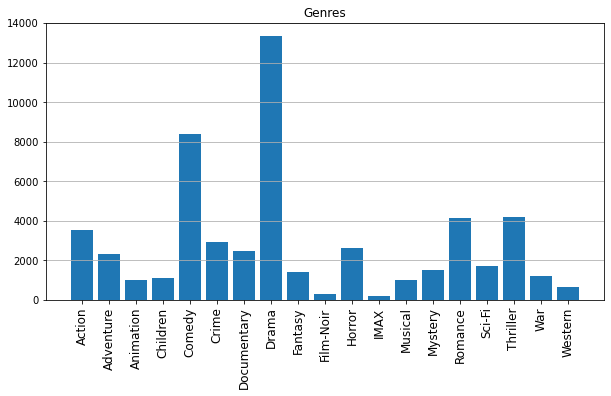

```python
# genres
gens = sorted(Genres.keys())

plt.figure(figsize=(10,5), dpi=72)
plt.bar(gens, [Genres[g] for g in gens])
plt.xticks(rotation=90, fontsize=12)
plt.grid(axis='y')
plt.title('Genres')
plt.show()
```

```python
# explore ratings data
Rating_Min, Rating_Max = df_ratings.rating.min(), df_ratings.rating.max()
print(Rating_Min, Rating_Max)
```

```
0.5 5.0
```

```python
# movies index
movies = df_ratings.movieId.unique()
MoviesIndex = {mov:i for i, mov in enumerate(movies)}
MoviesIndexRev = {MoviesIndex[mov]:mov for mov in MoviesIndex.keys()}

print(len(MoviesIndex.keys()), len(MoviesIndexRev.keys()))
```

```
26744 26744
```

```python
%%time

# rating matrix N-by-M, users-by-movies

# N = len(df_ratings.userId.unique())
N = USERS_N  # Full problem as above
M = len(MoviesIndex.keys())
Ratings = np.zeros((N,M), dtype=np.float32)

for _, row in df_ratings.iterrows():
    if row.userId > USERS_N:  # Shorten the problem dataset
        break
    Ratings[row.userId-1, MoviesIndex[row.movieId]] = row.rating
```

```
CPU times: total: 9.03 s
Wall time: 9.03 s
```

```python
# remove movies that have min number of ratings from the user list
RATINGS_N_MIN= 20

moviesnull = np.where(np.count_nonzero(Ratings, axis=0) <= RATINGS_N_MIN)[0]
moviesnull = [MoviesIndexRev[_] for _ in moviesnull]

print(len(moviesnull))
```

```
25038
```

```python
# movies index
movies = list(set(df_ratings.movieId.unique().tolist()) - set(moviesnull))
MoviesIndex = {mov:i for i, mov in enumerate(movies)}
MoviesIndexRev = {MoviesIndex[mov]:mov for mov in MoviesIndex.keys()}

print(len(MoviesIndex.keys()), len(MoviesIndexRev.keys()))
```

```
1706 1706
```

```python
# update the rating matrix
M = len(MoviesIndex.keys())
Ratings = np.zeros((N,M), dtype=np.float32)

for _, row in df_ratings.iterrows():
    if row.userId > USERS_N:  # Shorten the problem dataset
        break
    if row.movieId in MoviesIndex:  # Skip low count rated movies
        Ratings[row.userId-1, MoviesIndex[row.movieId]] = row.rating

print(Ratings.shape)  # number of users, number of movies
```

```
(1000, 1706)
```

```python
# sanity
moviesnull = np.where(np.count_nonzero(Ratings, axis=0) <= RATINGS_N_MIN)[0]

print(len(moviesnull))
```

```
0
```

```python
# distance metrics

def sim_jaccard(_a:np.ndarray, _b:np.ndarray)->float:
    ix = np.where((_a>0.) & (_b>0.))
    ixd = np.where((_a>0.) | (_b>0.))
    return ix[0].shape[0] / ixd[0].shape[0]

def sim_costeta(_a:np.ndarray, _b:np.ndarray)->float:
    from numpy.linalg import norm
    assert _a.shape == _b.shape, 'require vectors same shape'
    return np.dot(_a, _b) / (norm(_a)*norm(_b))

def sim_pearson(_a:np.ndarray, _b:np.ndarray)->float:
    ix = np.where((_a>0.) & (_b>0.))
    if ix[0].shape[0] == 0:
        return 0.
    _ua, _ub = np.mean(_a[ix]), np.mean(_b[ix])
    num = (_a[ix]-_ua) @ (_b[ix]-_ub).T
    den  = np.sqrt(np.sum((_a[ix]-_ua)**2)) * np.sqrt(np.sum((_b[ix]-_ub)**2))
    if den == 0.:
        return 0.
    return num/den

def dist_L1(_a:np.ndarray, _b:np.ndarray)->float:
    ix = np.where((_a>0.) & (_b>0.))
    if ix[0].shape[0] == 0:
        return 1.
    return np.sum(np.abs(_a[ix]-_b[ix])) / ix[0].shape[0]

def dist_L2(_a:np.ndarray, _b:np.ndarray)->float:
    ix = np.where((_a>0.) & (_b>0.))
    if ix[0].shape[0] == 0:
        return 1.
    return np.sqrt(np.sum((_a[ix]-_b[ix])**2)) / ix[0].shape[0]

def dist_cheby(_a:np.ndarray, _b:np.ndarray)->float:
    ix = np.where((_a>0.) & (_b>0.))
    if ix[0].shape[0] == 0:
        return 1.
    return np.max(_a[ix]-_b[ix]) / (Rating_Max-Rating_Min)

DistanceMetrics = [(sim_jaccard, 'Jaccard (sim)'), (sim_costeta, 'CosTeta (sim)'), (sim_pearson, 'Pearson (sim)'),
                   (dist_L1, 'L1 (dist)'), (dist_L2, 'L2 (dist)'), (dist_cheby, 'Chebyshev (dist)')]
```

```python
# distances
USER_A, USER_B = 0, 1

x1, x2 = Ratings[USER_A], Ratings[USER_B]

for metric in DistanceMetrics:
    print(f'{metric[1]:<17} {metric[0](x1, x2):.3f}')
```

```
Jaccard (sim)     0.053
CosTeta (sim)     0.133
Pearson (sim)     -0.069
L1 (dist)         1.167
L2 (dist)         0.412
Chebyshev (dist)  0.444
```

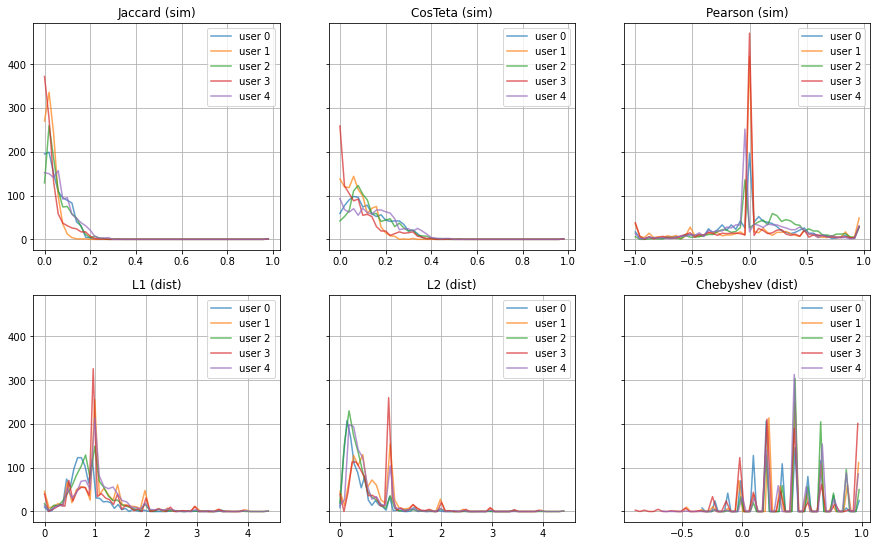

```python
Users = [0, 1, 2, 3, 4]

# example, user Users to other users histogram for these six distance metrics
fig, ax = plt.subplots(nrows=2, ncols=3, sharex='none', sharey='all', figsize=(15, 9), dpi=72)

for i, metric in enumerate(DistanceMetrics):
    for u in Users:
        d = [metric[0](Ratings[u], Ratings[_]) for _ in range(N)]
        h = np.histogram(d, bins=50)
        ax.flatten()[i].plot(h[1][:-1], h[0], label=f'user {u:d}', alpha=0.7)
    ax.flatten()[i].set_title(metric[1])
    ax.flatten()[i].legend(loc='upper right')
    ax.flatten()[i].grid()
```

## Collaborative Filtering

Online retailers, bookshops, and libraries sometimes have recommendations saying, "If you liked this popular book X, then you may also try this (not-so-much-popular) book Y." These remarks are directed toward a large group of people and often work well, and they are similar to a filtered chart. A stronger approach is to create individualized content lists or at least lists for small groups of like-minded users. A database of preferences for items by users to predict additional topics or products a new user might like.

### User-based Neighborhood-based Filtering

1. For a particular user compute the similarity to the *other users*
2. Order *users* by similarity
3. Select a *neighborhood of users* close to the *active user*
4. Compute the predicted rating from that neighborhood

### Item-based Filtering

1. For a particular item compute the similarity to the *other items*
2. Order *items* by similarity
3. Select a *neighborhood of items* close to the *active item*
4. Compute the predicted rating from that neighborhood

In both filtering the `Ratings` matrix will be used to compute similarities.

In an alternative approach, the item similarities might be computed using the **tags** and **tag scoring**. This would be equivalent to **content-based** approach. Note that tags are computed either by another pipeline or annotated/tagged by experts/users.

## User-based Example

- Find out what a user would score a particular movie that he/she did not score (or watch)
  - Similarity will be based on users
- Use `sim_costeta` for similarity (can try other ones)
- Distance matrix is `N`-by-`N`
- Always use `float32` for speed

```python
# User-based filtering
OUR_USER= 0
OUR_ITEM= 0  # pick an item which our user did not rate
OUR_USER_NEIGHBORHOOD= 50  # number of users similar to our user
```

```python
# users who rated our item
ix_users = np.where(Ratings[:,OUR_ITEM]>0.)[0]
```

```python
%%time

# generate a distance matrix - user
Dist_u = np.zeros((N,N), dtype=np.float32)
for i in range(N):
    for j in range(N):
        Dist_u[i,j] = sim_costeta(Ratings[i,:], Ratings[j,:])
```

```
CPU times: total: 5.55 s
Wall time: 5.55 s
```

```python
# Pearson generates -1 to +1
d = np.abs(Dist_u[OUR_USER,ix_users])
ix_best = np.argsort(-d)[:OUR_USER_NEIGHBORHOOD]
users = ix_users[ix_best]
```

```python
Dist_u[OUR_USER,users]
```

```
array([0.40457195, 0.376088  , 0.3636198 , 0.36297017, 0.36068535,
       0.35957903, 0.35941103, 0.35755163, 0.3565974 , 0.34926307,
       0.34772184, 0.3475802 , 0.34442246, 0.34433424, 0.34246457,
       0.3385418 , 0.33742315, 0.3373577 , 0.3327701 , 0.33230612,
       0.3305398 , 0.3281719 , 0.3254474 , 0.32429686, 0.32400984,
       0.32379663, 0.32297403, 0.3224957 , 0.32155728, 0.32003078,
       0.3195294 , 0.31799585, 0.31655583, 0.31534153, 0.31273744,
       0.31241196, 0.3090288 , 0.30858234, 0.3075587 , 0.3062176 ,
       0.30284712, 0.30217868, 0.30106026, 0.29852498, 0.29817006,
       0.29561612, 0.29506028, 0.2946949 , 0.2922781 , 0.2906266 ],
      dtype=float32)
```

```python
ratings = np.array([Ratings[_,OUR_ITEM] for _ in users])

print(f'The user not rated the item= {Ratings[OUR_USER, OUR_ITEM]:.1f}')
print(f'Average rating in user-neighborhood= {ratings.mean():.1f}')
```

```
The user not rated the item= 0.0
Average rating in user-neighborhood= 3.9
```

**Outcome:** The user did not rate the item. Other users in the neighborhood of this user rated the item with the average as above.

## Item-based Example

- Find out what a user would score a particular movie that he/she did not score (or watch)
  - Similarity will be based on items
- Use `sim_costeta` for similarity (can try other ones)
- Distance matrix is `M`-by-`M`
- Always use `float32` for speed

```python
# Item-based filtering
OUR_USER= 0
OUR_ITEM= 0  # pick an item which our user did not rate
OUR_ITEM_NEIGHBORHOOD= 50  # number of items similar to our item
```

```python
# users who rated our item
users = np.where(Ratings[:,OUR_ITEM]>0.)[0]
```

```python
%%time

# generate a distance matrix - item
Dist_i = np.zeros((M,M), dtype=np.float32)
for i in range(M):
    for j in range(M):
        Dist_i[i,j] = sim_costeta(Ratings[:,i], Ratings[:,j])
```

```
CPU times: total: 26.1 s
Wall time: 26.1 s
```

```python
d = np.abs(Dist_i[OUR_ITEM,:])
ix_best = np.argsort(-d)[:OUR_ITEM_NEIGHBORHOOD]
items = ix_best
```

```python
Dist_i[OUR_ITEM,items]
```

```
array([1.        , 0.5504396 , 0.5502418 , 0.5399177 , 0.53434914,
       0.5339682 , 0.5261372 , 0.52247614, 0.5207451 , 0.5182745 ,
       0.5171993 , 0.5162483 , 0.5151485 , 0.51244044, 0.5092254 ,
       0.5065545 , 0.49518365, 0.49036434, 0.48994136, 0.48688045,
       0.48679808, 0.4855667 , 0.48526853, 0.4845558 , 0.48364452,
       0.4789724 , 0.47775424, 0.47728276, 0.47648945, 0.47547597,
       0.4751349 , 0.47399274, 0.47177908, 0.4688636 , 0.46806997,
       0.46561712, 0.46376756, 0.46283498, 0.46212852, 0.45594773,
       0.4524766 , 0.4489189 , 0.44841185, 0.44607133, 0.44498888,
       0.44414526, 0.44198734, 0.44049805, 0.4375241 , 0.43522343],
      dtype=float32)
```

```python
ratings = np.array([Ratings[users,_] for _ in items])

print(f'The user not rated the item= {Ratings[OUR_USER, OUR_ITEM]:.1f}')
print(f'Average rating in item-neighborhood= {ratings.mean():.1f}')
```

```
The user not rated the item= 0.0
Average rating in item-neighborhood= 1.8
```

**Outcome:** The user did not rate the item. Other items in the neighborhood of this item has the average score as above.

## Content-based Approach: Cluster the Items

Item category can help a user to select a relevant item. In addition, the user selections and scores can guide the recommender system to predict what category a user likes more than the others. Creating item genres or item categories can be accomplished via clustering item features. These features can be also some augmented information provided by experts (or even movie critics). In this example, we can use movie titles (plots, information extracted from Web, or even parsing movie scripts) to create a movie feature vector. Note that in our dataset there are also tags which capture this kind of information.

Use the following two resources:

1. `gensim` GloVe [Gensim](https://radimrehurek.com/gensim/index.html) = "Generate Similar" is a topic modeling library to implement Latent Semantic Methods and it is licensed under [GNU LGPLv2.1 license](https://www.gnu.org/licenses/old-licenses/lgpl-2.1.en.html)
2. GloVe embedding model with feature size `M=100` using https://nlp.stanford.edu/projects/glove/

`gensim` library can download GloVe word embeddings to be used as word vectors in text processing. A movie is represented by its title and the average of the word vectors it constitutes (Word2Vec is another method to represent a text phrase).

GloVe project is an embedding approach trained by very large corpora and specifically indexed words in a consistent manner in order to improve sharing across problems and domains. The selected embedding is `M=100` dimensions, 400K words.

The number of genres might be a good starting point as the number of clusters expected.

Let's represent each movie by its average word embedding extracted from its title and cluster.

```python
import gensim
import gensim.downloader

print(f'gensim version= {gensim.__version__}')
Glove = gensim.downloader.load('glove-wiki-gigaword-100')

GLOVE_M = 100
```

```
gensim version= 4.3.0
```

```python
# restart movie index due to filtering as in the previous Cells
movies = sorted(df_ratings.movieId.unique())
MoviesIndex = {mov:i for i, mov in enumerate(movies)}
MoviesIndexRev = {MoviesIndex[mov]:mov for mov in MoviesIndex.keys()}

M_titles = len(MoviesIndex.keys())
```

```python
# populate titles, extract tokens
Titles, TitleGenres, TitlesParsed = [None]*M_titles, [None]*M_titles, [None]*M_titles
for _, row in df_movies.iterrows():
    if row.movieId in MoviesIndex:
        Titles[MoviesIndex[row.movieId]] = row.title
        TitleGenres[MoviesIndex[row.movieId]] = re.search(r'[\w\-]+', row.genres).group(0)  # use only the first one

for _, title in enumerate(Titles):
    TitlesParsed[_] = re.findall(r'[a-z]+', title.lower())

# sanity
print(Titles[:5])
print(TitlesParsed[:5])
print(TitleGenres[:5])
```

```
['Toy Story (1995)', 'Jumanji (1995)', 'Grumpier Old Men (1995)', 'Waiting to Exhale (1995)', 'Father of the Bride Part II (1995)']
[['toy', 'story'], ['jumanji'], ['grumpier', 'old', 'men'], ['waiting', 'to', 'exhale'], ['father', 'of', 'the', 'bride', 'part', 'ii']]
['Adventure', 'Adventure', 'Comedy', 'Comedy', 'Comedy']
```

```python
# take the average word vectors to represent titles in GloVe embeddings
X = np.zeros((M_titles, GLOVE_M), dtype=np.float32)
for _, title in enumerate(TitlesParsed):
    v = []
    if len(title) == 0:
        # movie title empty after parsing, setting to zero vector
        X[_] = np.zeros(GLOVE_M, dtype=np.float32)
    else:
        for w in title:
            v += [Glove[w]] if w in Glove else [np.zeros(GLOVE_M, dtype=np.float32)]
        X[_] = np.mean(np.array(v), axis=0)  # average
```

```python
from sklearn.cluster import KMeans

# use number of genres to cluster
K = len(Genres.keys())
Clusters = KMeans(n_clusters=K, n_init=10).fit_predict(X)
```

```python
# Print a few movie titles and their cluster IDs in a genre
GENRE = 'Horror'
n_results = 20
for _, g in enumerate(TitleGenres):
    if g == GENRE and n_results > 0:
        print(f'{Clusters[_]:2d}  {Titles[_]:s}')
        n_results -= 1
```

```
 6  Lord of Illusions (1995)
 0  Species (1995)
16  Castle Freak (1995)
 5  Relative Fear (1994)
 6  Tales from the Crypt Presents: Demon Knight (1995)
12  Village of the Damned (1995)
12  Fear, The (1995)
12  In the Mouth of Madness (1995)
16  Body Snatchers (1993)
 6  Puppet Masters, The (1994)
 2  301, 302 (301/302) (1995)
16  Cemetery Man (Dellamorte Dellamore) (1994)
 4  Thinner (1996)
12  Spirits of the Dead (1968)
16  Eyes Without a Face (Yeux sans visage, Les) (1959)
 6  Relic, The (1997)
 6  Halloween: The Curse of Michael Myers (Halloween 6: The Curse of Michael Myers) (1995)
12  Night of the Living Dead (1968)
12  Children of the Corn IV: The Gathering (1996)
12  Fog, The (1980)
```

```python
# Print a few movie titles and their cluster IDs in a genre
GENRE = 'War'
n_results = 20
for _, g in enumerate(TitleGenres):
    if g == GENRE and n_results > 0:
        print(f'{Clusters[_]:2d}  {Titles[_]:s}')
        n_results -= 1
```

```
11  Pharaoh's Army (1995)
10  Walk in the Sun, A (1945)
 6  Prisoner of the Mountains (Kavkazsky plennik) (1996)
 4  Pork Chop Hill (1959)
10  Run Silent Run Deep (1958)
12  Cross of Iron (1977)
 6  Devil's Brigade, The (1968)
13  Story of G.I. Joe (1945)
18  Anzio (1968)
12  Lion of the Desert (1980)
11  Attack Force Z (a.k.a. The Z Men) (Z-tzu te kung tui) (1982)
 5  Objective, Burma! (1945)
12  Battle of Britain (1969)
 3  Duel at Diablo (1966)
11  Murphy's War (1971)
 6  Plainsman, The (1937)
12  In Enemy Hands (2004)
15  Bataan (1943)
 3  Villa Rides! (1968)
 6  Battle for Haditha (2007)
```

**Question:** How do you assess the performance of this clustering? Do you expect above clustering will work on titles for other genres?

## References

1. Falk, Kim. Practical recommender systems. Simon and Schuster, 2019.
2. Harper, F. Maxwell, and Joseph A. Konstan. "The movielens datasets: History and context." Acm transactions on interactive intelligent systems (tiis) 5.4 (2015): 1-19.
3. Su, Xiaoyuan, and Taghi M. Khoshgoftaar. "A survey of collaborative filtering techniques." Advances in artificial intelligence 2009 (2009).

## Exercises

**Exercise 1.** Reduce the number of items by updating the minimum number of ratings and rerun the analysis.

**Exercise 2.** Why the item filtering revealed a much lower rating compared to the user? How do you remedy?

**Exercise 3.** Implement content based filtering by generating similarities between movies based on their tags.

```python
%%html
<style>
    table {margin-left: 0 !important;}
</style>
<!-- Display markdown tables left oriented in this notebook. -->
```